# Sigmoid neuroner

Fra perceptroner til kunstige neurale netværk. Her behandles "Sigmoid neuroner", som er en udvidelse af den klassiske perceptron og dermed en trædesten på vej mod at forstå kunstige neurale netværk.

Hvis du ikke har læst noten om perceptroner, anbefaler vi, at du starter med at læse den. Alternativt kan du se vores fire [videoer om perceptroner](https://www.youtube.com/watch?v=1WTZZCx-pRY&list=PLIdWoTbMPdkBdcpyMZYpBkQzRUsSHYXoP).

## Kan vi gøre det bedre end ADALINE?

I noten om perceptroner beskrev vi perceptron learning algoritmen, som altid konvergerer, hvis data er lineært separabel. Men verden er sjældent lineært separabel, og derfor introducerede vi ADALINE algoritmen, som også virker, selvom data ikke er lineært separabel. Det virker jo alt sammen super godt – men et enkelt lille eksempel afslører alligevel, at ADALINE ikke altid er så smart, som man kunne tro.

Vi vil se på data i nedenstående tabel

| $x_1$ | $x_2$ | Targetværdi |
| --- | --- | --- |
| $-0.5$ | $0.5$ | $1$ |
| $-0.3$ | $0.3$ | $1$ |
| $-0.1$ | $0.7$ | $1$ |
| $0.1$ | $0.4$ | $-1$ |
| $-0.1$ | $0.2$ | $-1$ |
| $0.1$ | $-0.1$ | $-1$ |

I figur 1 har vi indtegnet punkterne $(x_1,x_2)$ og farvet punkterne med en targetværdi på $1$ blå og dem med en targetværdi på $-1$ røde.

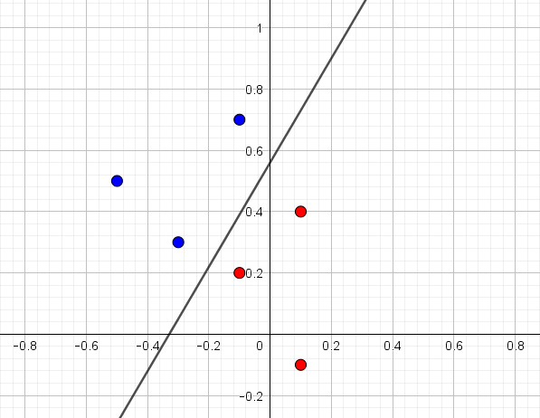

Figur 1: Punkter med en targetværdi på $1$ er blå og dem med en targetværdi på $-1$ er røde.

Det er tydeligt, at punkterne er lineært separabel og den indtegnede linje er også den som ADALINE giver[^1]. Du kan selv prøve [ADALINE her](https://apps01.math.aau.dk/adaline/). De estimerede vægte er $w_0=-0.9346, w_1=-2.838$ og $w_2=1.668$.Det vil sige, at den indtegnede linje har ligning

<sup>1</sup> Her er alle startvægte sat til $0$, learning rate er på $0.1$, stop-kriterie er på $0.000001$ og maksimalt antal iterationer er sat til $50000$.

$$-0.9346-2.838 x_1 + 1.668x_2=0$$

Det er alt sammen meget fint, men lad os nu prøve at indtegne et nyt rødt punkt:

| $x_1$ | $x_2$ | Targetværdi |
| --- | --- | --- |
| $1$ | $-1$ | $-1$ |

Det nye punkt er indtegnet i figur 2 sammen med de øvrige seks punkter. Det er tydeligt, at data stadig er lineært separabel.

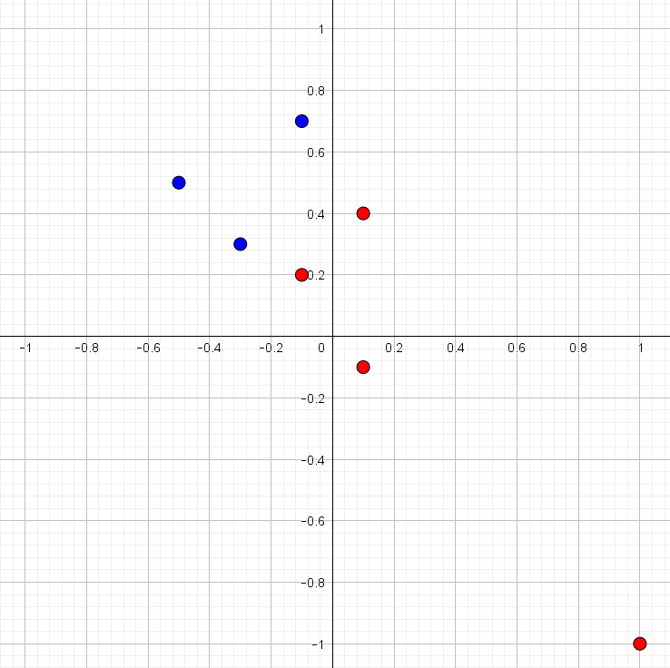

Figur 2: Et nyt rødt punkt er indtegnet og data er stadig lineært separabel.

Hvis vi prøver at køre ADALINE algoritmen fås linjen, som er indtegnet i figur 3. Vi kan allerede se nu, at det er helt skørt. Data er lineært separabel, men alligevel er der et rødt punkt, som bliver klassificeret forkert – faktisk var den oprindelige linje fra figur 1 bedre.

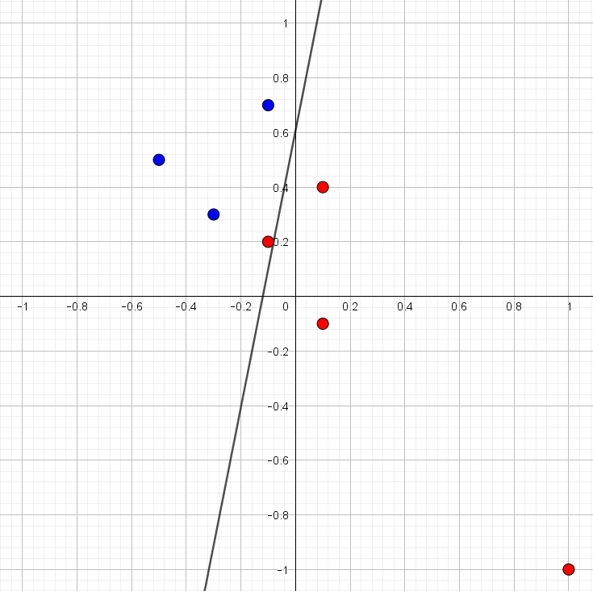

Figur 3: Et nyt rødt punkt er indtegnet og den linje, som ADALINE finder.

Det er jo ikke ligefrem super overbevisende. Data er lineært separabel og alligevel kan ADALINE ikke finde ud af at finde en rette linje, som kan adskille de røde punkter fra de blå!

Hvis vi skal forstå, hvad der sker, må vi se lidt nærmere på den tabsfunktion, som ADALINE forsøger at mininere. Fra afsnittet om ADALINE ved vi, at tabsfunktionen[^2] er

<sup>2</sup> Bemærk her, at det ikke er afgørende, at der er ganget med $1/2$ – det viser sig bare smartere senere.

$$\begin{aligned}
E(w_0, w_1, &\dots, w_n)\\ &= \frac{1}{2} \sum_{m=1}^{M} \left (t_m-
(w_0 + w_1 \cdot x_{m,1} + \cdots + w_n \cdot x_{m,n}) \right)^2
\end{aligned}$$

hvor det $m$’te træningseksempel er
$$(x_{m,1}, x_{m,2}, \dots, x_{m,n}, t_m)$$

Det vil sige, at det $m$’te træningseksempel giver et bidrag til tabsfunktionen på

$$\left ( t_m- (w_0 + w_1 \cdot x_{m,1} + \cdots + w_n \cdot x_{m,n}) \right)^2$$

For et blåt punkt med $t_m=1$ vil det sige, at bidraget til tabsfunktionen er præcis $0,$ hvis
$$1- (w_0 + w_1 \cdot x_{m,1} + \cdots + w_n \cdot x_{m,n})=0$$
og for et rødt punkt med $t_m=-1$ er bidraget til tabsfunktionen præcis $0,$ hvis
$$-1- (w_0 + w_1 \cdot x_{m,1} + \cdots + w_n \cdot x_{m,n})=0$$
Nu er $1- (w_0 + w_1 \cdot x_1 + \cdots + w_n \cdot x_n)=0$ og $-1- (w_0 + w_1 \cdot x_1 + \cdots + w_n \cdot x_n)=0$ jo bare ligninger for rette linjer[^3]. Disse linjer ses indtegnet på figur 4 (som henholdsvis en blå og rød stiplet linje) sammen med de oprindelige seks punkter og den linje, som ADALINE fandt baseret på disse seks punkter. Samtidig er det for hvert punkt markeret, hvor meget dette punkt bidrager til tabsfunktionen.

<sup>3</sup> Det er i hvert tilfælde "bare linjer", når $n=2$. Hvis $n=3$, er der tale om ligningen for en plan, og hvis $n>3$, kalder man det for ligningen for en "hyperplan". Men sidstnævnte er visuelt svære at forestille sig, fordi koordinatsystemet, disse hyperplaner skal tegnes i, har en dimension større end $3$. Og de er ikke så nemme at tegne!

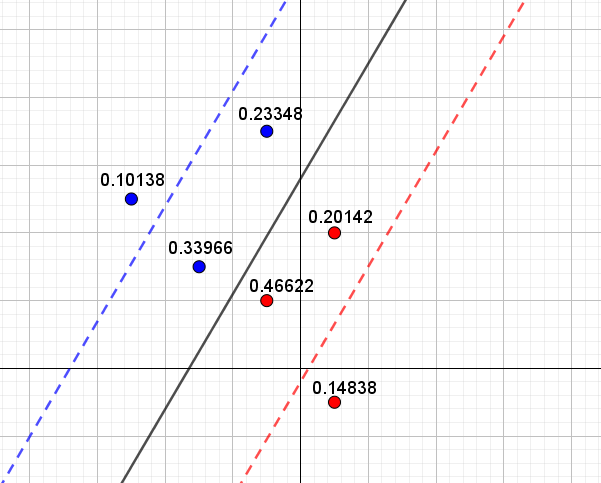

Figur 4: Punkter med en targetværdi på $1$ er blå og dem med en targetværdi på $-1$ er røde. Den sorte linje med ligning $w_0+w_1 x_1 + w_2 x_2=0$ svarer til den ADALINE fandt. Den blå stiplede linje har ligning $1-(w_0+w_1 x_1 + w_2 x_2)=0$, mens den røde stiplede linje har ligning $-1-(w_0+w_1 x_1 + w_2 x_2)=0$.

Det ses nu på figur 4, at blå punkter, som ligger tæt på den blå stiplede linje, bidrager mindst til tabsfunktionen, mens røde punkter, som ligger tæt på den røde stiplede linje, ligeledes bidrager mindst til tabsfunktionen. Den samlede værdi af tabsfunktionen er her $0.75$.

Laver vi nu samme øvelse med det ekstra punkt fås resultat i figur 5.

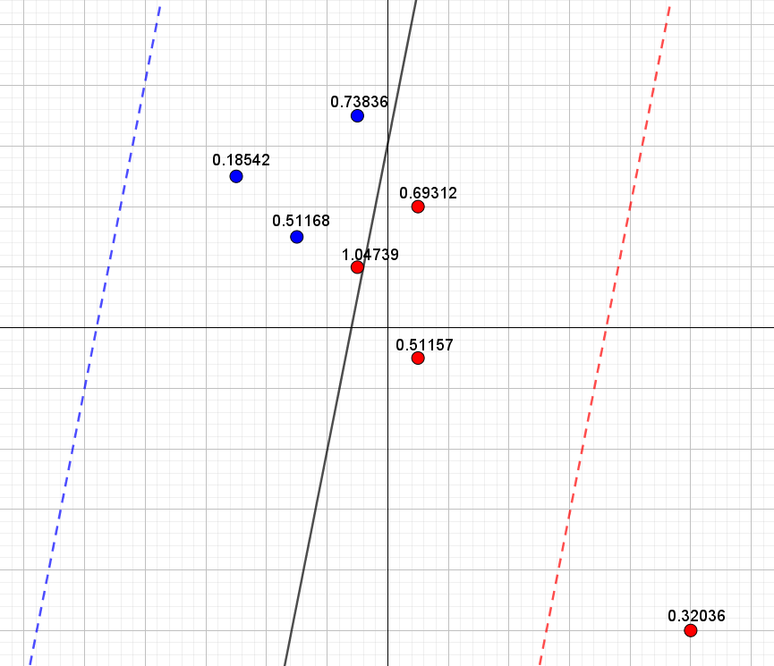

Figur 5: I alt syv punkter sammen med den sorte linje med ligning $w_0+w_1 x_1 + w_2 x_2=0$ svarer til den ADALINE finder. Punkter med en targetværdi på $1$ er blå og dem med en targetværdi på $-1$ er røde. Den blå stiplede linje har ligning $1-(w_0+w_1 x_1 + w_2 x_2)=0$, mens den røde stiplede linje har ligning $-1-(w_0+w_1 x_1 + w_2 x_2)=0$. Den samlede værdi af tabsfunktionen er her $2.00$.

Igen ser vi, at blå punkter tæt på den blå stiplede linje bidrager mindst til tabsfunktionen og tilsvarende for de røde punkter, som ligger tæt på den røde stiplede linje. Det nye punkts bidrag til tabsfunktionen bliver derfor her det mindste bidrag blandt alle de røde punkter. Den samlede værdi af tabsfunktionen er her $2.00$.

Hvis vi i stedet prøver at bruge vores egen oprindelige linje (baseret på de seks første punkter), som rent faktisk kunne adskille de blå punkter fra de røde, så fås det resultat, som ses i figur 6.

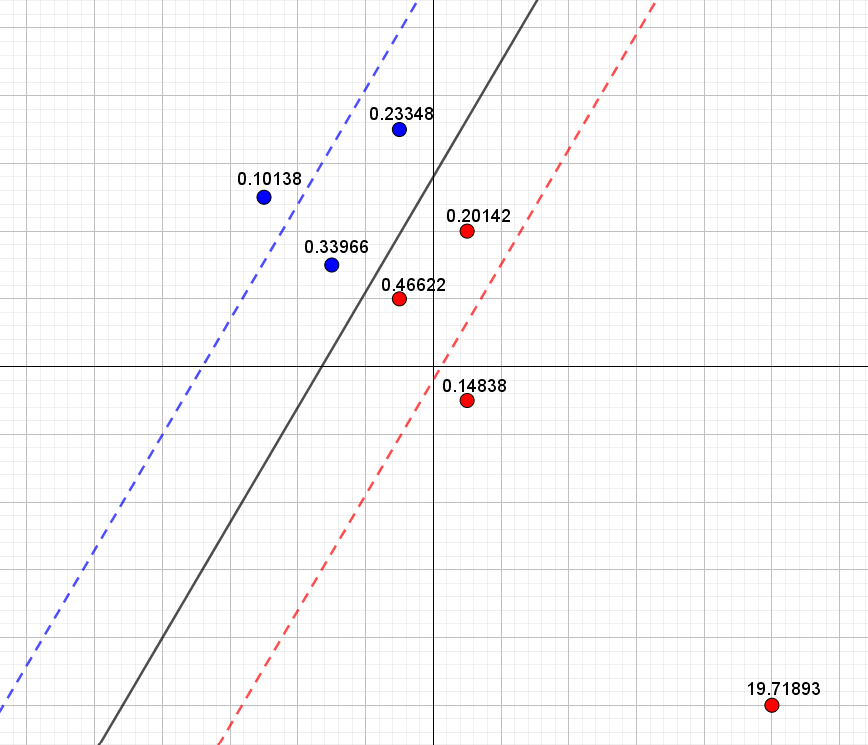

Figur 6: I alt syv punkter sammen med den sorte linje, som ADALINE giver baseret på de oprindelige seks punkter. Punkter med en targetværdi på $1$ er blå og dem med en targetværdi på $-1$ er røde. Den blå stiplede linje har ligning $1-(w_0+w_1 x_1 + w_2 x_2)=0$, mens den røde stiplede linje har ligning $-1-(w_0+w_1 x_1 + w_2 x_2)=0$. Den samlede værdi af tabsfunktionen er her $10.60$.

## Sigmoid neuron og aktiveringsfunktioner

Problemet med ADALINE, som vi har set i eksemplet ovenfor, opstår fordi, et *ekstremt* punkt får lov til at "trække" uforholdsmæssigt meget i den linje, som ADALINE finder, for at dette punkts bidrag til tabsfunktionen ikke skal blive alt for stort.

Vi så det i figur 5 og figur 6. I figur 5 brugte vi den linje, som ADALINE gav, og her var det *ekstreme* punkts bidrag til tabsfunktionen på $0.32$. I figur 6 valgte vi en linje, som oplagt er bedre til at adskille de blå punkter fra de røde, men her er det *ekstreme* punkts bidrag til tabsfunktionen helt oppe på $19.72$.

For at forstå det lidt bedre skal vi måske lige repetere, hvordan man finder afstanden fra et punkt $P(x_1,y_1)$ til en linje $l$ med ligning $ax+by+c=0$:

$$\textrm{dist}(P,l)=\frac{|a x_1 + b y_1 +c|}{\sqrt{a^2+b^2}}$$

Denne afstandsformel kan generaliseres, så afstanden fra et punkt $P(x_{m,1}, x_{m,2}, \dots, x_{m,n})$ (i et $n$-dimensionalt rum!) til linjen $l$ med ligning $w_0+w_1 x_1 + w_2 x_2 + \cdots + w_n x_n=0$ er:

$$\textrm{dist}(P,l)=\frac{|w_0 + w_1 \cdot x_{m,1} + \cdots + w_n \cdot x_{m,n}|}{\sqrt{w_1^2 + w_2^2 + \cdots + w_n^2}}$$

Det vil sige, at udtrykket i tælleren $|w_0 + w_1 \cdot x_{m,1} + \cdots + w_n \cdot x_{m,n}|$ bliver et mål for hvor langt væk punktet $P(x_{m,1}, x_{m,2}, \dots, x_{m,n})$ ligger fra linjen. Det forklarer, hvordan et *ekstremt* punkt kan give et meget stort bidrag til tabsfunktionen:

$$\left ( t- (w_0 + w_1 \cdot x_{m,1} + \cdots + w_n \cdot x_{m,n}) \right)^2
\tag{1}$$

Hvis punktet ligger langt væk fra den linje, som måske umiddelbart ser fornuftig ud, så vil punktet give et stort bidrag til tabsfunktionen, fordi værdien af $w_0 + w_1 \cdot x_{m,1} + \cdots + w_n \cdot x_{m,n}$ bliver stor, og dermed vil bidraget til tabsfunktionen i (1) også blive stort!

Alt det her leder os frem til, at valget af tabsfunktion måske i virkeligheden ikke er super smart. Problemet opstår grundlæggende, fordi targetværdien $t$ og udtrykket i den inderste parentes i (1) er på to helt vidt forskellige skalaer. Targetværdien er enten $-1$ eller $1$, mens udtrykket $w_0 + w_1 \cdot x_{m,1} + \cdots + w_n \cdot x_{m,n}$ kan antage en hvilken som helst reel værdi – en værdi som kan blive vældig stor, hvis punktet $P(x_{m,1}, x_{m,2}, \dots, x_{m,n})$ ligger langt væk fra linjen. Derfor bliver ADALINE nødt til at tvinge linjen med ligningen

$$w_0 + w_1 \cdot x_{1} + \cdots + w_n \cdot x_{n}=0$$

over mod et ekstremt punkt, sådan at dette punkts bidrag til tabsfunktionen ikke bliver alt for stort.

Problemet kan løses ved at bruge det, man kalder for en *aktiveringsfunktion*. Helt grundlæggende handler det om, at targetværdi $t,$ og det udtryk som vi beregner på baggrund af punktet $P(x_{m,1}, x_{m,2}, \dots, x_{m,n})$ skal være på samme skala. Vi vil her illustrere det ved at bruge en aktiveringsfunktion, som ofte benyttes, og som kaldes for "sigmoid"-funktionen $\sigma$. Forskriften for sigmoid-funktionen er:

$$\sigma(x)=\frac{1}{1+e^{-x}}
\tag{2}$$

Grafen for sigmoid-funktionen ses i figur 7.

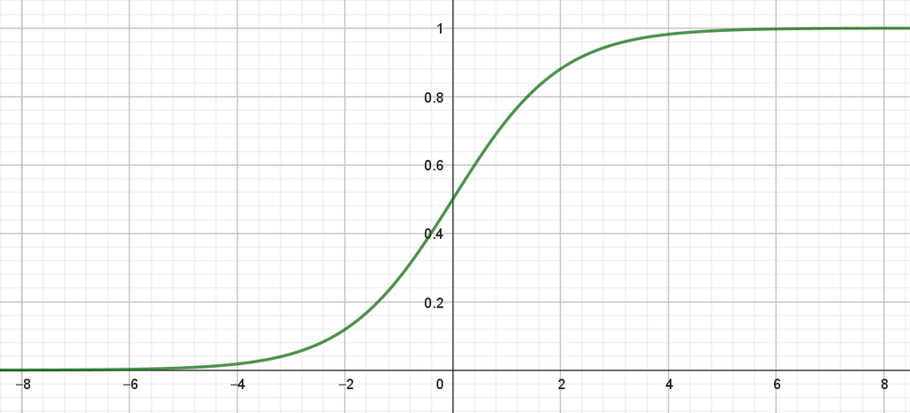

Figur 7: Grafen for sigmoid-funktionen med forskrift $\sigma(x)=\frac{1}{1+e^{-x}}$.

Definitionsmængden for sigmoid-funktionen er alle reelle tal, mens værdimængden er intervallet $(0,1)$. Det kan skrives sådan her:

$$\sigma: \mathbb{R} \rightarrow (0,1)$$

Det vil vi udnytte og nu omdefinere targetværdien $t$ på denne måde:

$$t=
\begin{cases}
1 & \textrm{hvis punktet er blåt} \\
0 & \textrm{hvis punktet er rødt} \\
\end{cases}$$

Så targetværdierne er nu $0$ eller $1$ i stedet for $-1$ og $1$. Vi definerer nu tabsfunktionen sådan her:

$$\begin{aligned}
E(w_0, w_1, &\dots, w_n) \\ &= \frac{1}{2} \sum_{m=1}^{M} \left (t_m-
\sigma(w_0 + w_1 \cdot x_{m,1} + \cdots + w_n \cdot x_{m,n}) \right)^2
\end{aligned}
\tag{3}$$

Bemærk, at problemet med de to skalaer nu er løst. Targetværdien er enten $0$ eller $1$ samtidig med, at $\sigma(w_0 + w_1 \cdot x_{m,1} + \cdots + w_n \cdot x_{m,n})$ også ligger mellem $0$ og $1$. Vi sammenligner altså ikke længere pærer med bananer! Når sigmoid-funktionen på denne måde indgår i en tabsfunktion, så kalder man den også for en **aktiveringsfunktion**. Og den "perceptron" som minimerer tabsfunktionen i (3) kaldes for en **sigmoid neuron**.

Lad os nu undersøge hvordan vi får en lille værdi af tabsfunktionen. Hvis punktet er blåt (svarende til en targetværdi på $1$), så vil bidraget

$$\left (1 - \sigma(w_0 + w_1 \cdot x_{m,1} + \cdots + w_n \cdot x_{m,n}) \right)^2$$

være lille (altså sæt på $0$), hvis $\sigma(w_0 + w_1 \cdot x_{m,1} + \cdots + w_n \cdot x_{m,n})$ er tæt på $1$. Og omvendt hvis targetværdien er $0$ (hvilket svarer til et rødt punkt), så vil bidraget

$$\left (0 - \sigma(w_0 + w_1 \cdot x_{m,1} + \cdots + w_n \cdot x_{m,n}) \right)^2$$

være lille (altså sæt på $0$), hvis $\sigma(w_0 + w_1 \cdot x_{m,1} + \cdots + w_n \cdot x_{m,n})$ er tæt på $0$. Vi leder altså efter vægte $w_0, w_1, \dots, w_n$, som netop har denne egenskab, fordi de så vil minimere tabsfunktionen.

Dette har også en anden fordel. Vi kan nemlig tænke på værdi

$$\sigma(w_0 + w_1 \cdot x_{m,1} + \cdots + w_n \cdot x_{m,n})$$

som en sandsynlighed for at punktet $P(x_{m,1}, x_{m,2}, \dots, x_{m,n})$ er blåt. Vi kan derfor bruge denne værdi til at forudsige om et nyt punkt er blåt eller rødt. Det vil vi gøre på denne måde:

$$\textrm{Nyt punkt er }=
\begin{cases}
\textrm{blåt} & \textrm{hvis } \sigma(w_0 + \cdots + w_n \cdot x_{m,n}) \geq 0.5\\
\textrm{rødt} & \textrm{hvis } \sigma(w_0 + \cdots + w_n \cdot x_{m,n}) < 0.5\\
\end{cases}
\tag{4}$$

Skillelinjen for hvornår et punkt $(x_1, x_2, \dots, x_n)$ er blåt eller rødt fås netop, når

$$\sigma(w_0 + w_1 \cdot x_{1} + \cdots + w_n \cdot x_{n}) = 0.5
\tag{5}$$

Ser vi på definitionen af sigmoid-funktionen i (2) svarer det til at løse

$$\sigma(x)=\frac{1}{1+e^{-x}} = 0.5$$

Dette er netop opfyldt, hvis $e^{-x}=1$, hvilket kun kan lade sig gøre, når $x=0$. Sammenligner vi dette med (5), så ser vi altså at skillelinjen er

$$w_0 + w_1 \cdot x_{1} + \cdots + w_n \cdot x_{n} = 0$$

Den nye måde at tænke tabsfunktionen på giver os altså stadigvæk en ret linje, som kan bruges til at adskille de røde punkter fra de blå.

Lad os prøve først at illustrere det med datasættet bestående af de seks punkter i figur 1. Resultat af at bruge ADALINE (fuldt optrukket linje) og en sigmoid neuron (stiplet linje) ses i figur 8. Det er her tydeligt, at begge metoder kan bruges til at finde en linje, som adskiller de blå punkter fra de røde, og der er i det hele taget ikke den store forskel på de to metoder.

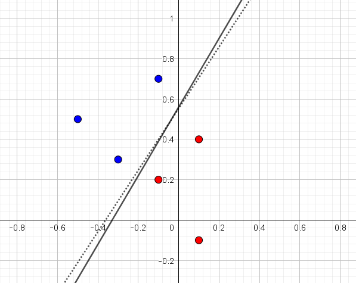

Figur 8: Fuldt optrukket linje svarer til ADALINE – stiplet linje svarer til sigmoid neuron.

Bruger vi nu ADALINE og en sigmoid neuron på data fra figur 2 fås resultatet i figur 9. Igen svarer ADALINE til fuldt optrukket linje og sigmoid til stiplet linje. Vi kan nu se, at sigmoid neuron præcis gør det, som vi havde håbet på: Den adskiller de blå punkter fra de røde også selvom ét af punkterne er ekstremt.

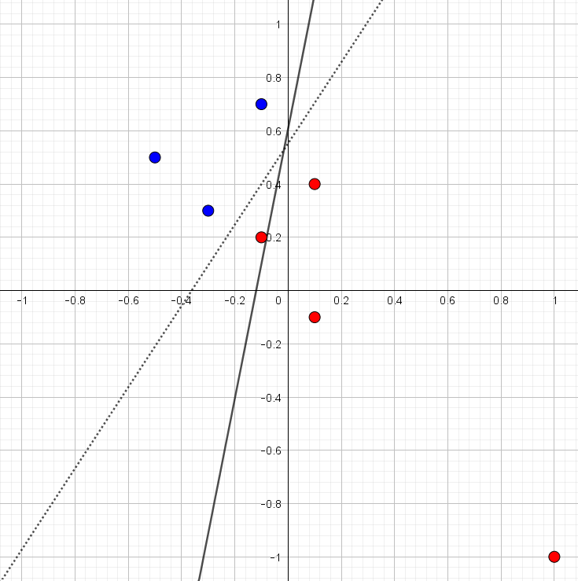

Figur 9: Fuldt optrukket linje svarer til ADALINE – stiplet linje svarer til sigmoid neuron.

Vægtene fra sigmoid neuronen i det sidste eksempel er $w_0=-6.046$, $w_1=-16.69$ og $w_2=10.94$ svarende til linjen med ligning
$$-6.046 - 16.69x_1+10.94x_2=0$$
Udregner vi
$$\sigma(-6.046 - 16.69x_1+10.94x_2)$$
får vi altså sandsynligheden for at et punkt er blåt. Gør vi det fås resultatet i nedenstående tabel:

| $x_1$ | $x_2$ | Targetværdi | Sandsynlighed |
| --- | --- | --- | --- |
| $-0.5$ | $0.5$ | $1$ | $1.00$ |
| $-0.3$ | $0.3$ | $1$ | $0.90$ |
| $-0.1$ | $0.7$ | $1$ | $0.96$ |
| $0.1$ | $0.4$ | $0$ | $0.03$ |
| $-0.1$ | $0.2$ | $0$ | $0.10$ |
| $0.1$ | $-0.1$ | $0$ | $0.00$ |
| $1$ | $-1$ | $0$ | $0.00$ |

Der er her fin overensstemmelse mellem targetværdien og den beregende sandsynlighed. Læg også mærke til at det ekstreme punkt har en beregnet sandsynlighed på $0.00$ og dermed bliver prædikteret til klart at være et *ikke* blåt – det vil sige et rødt – punkt.

## Nye opdateringsregler

I noten om perceptroner forklarede vi i afsnittet om gradientnedstigning, hvordan vægtene i ADALINE algoritmen blev opdateret. Vi vil her på tilsvarende vis udlede de nye opdateringsregler for sigmoid neuronen.

Vi har nu tabsfunktionen

$$\begin{aligned}
E(w_0, w_1, &\dots, w_n) \\ &= \frac{1}{2} \sum_{m=1}^{M} \left (t_m-
\sigma(w_0 + w_1 \cdot x_{m,1} + \cdots + w_n \cdot x_{m,n}) \right)^2
\end{aligned}$$

som vi igen vil minimere ved at bruge gradientnedstigning. Det vil sige, at vægtene opdateres ved at gå et lille stykke i den negative gradients retning:

$$\begin{aligned}
w_0 \leftarrow & w_0 - \eta \cdot \frac{\partial E }{\partial w_0} \\
w_1 \leftarrow & w_1 - \eta \cdot \frac{\partial E }{\partial w_1} \\
&\vdots \\
w_n \leftarrow & w_n - \eta \cdot \frac{\partial E }{\partial w_n} \\
\end{aligned}$$

hvor $\eta$ er en *learning rate*.

Vi bestemmer nu den partielle afledede for den $i$’te vægt. Ved at bruge sum- og kædereglen får vi:

$$\begin{aligned}
\frac{\partial E}{\partial w_i} &= \frac{1}{2} \sum_{m=1}^{M} \frac{\partial}{\partial w_i}\left (t_m-
\sigma(w_0 + w_1 \cdot x_{m,1} + \cdots + w_n \cdot x_{m,n}) \right)^2 \\
&= \frac{1}{2} \sum_{m=1}^{M} 2 \cdot \left (t_m-
\sigma(w_0 + w_1 \cdot x_{m,1} + \cdots + w_n \cdot x_{m,n}) \right) \\
& \quad \quad \quad \quad \cdot \frac{\partial}{\partial w_i} \left (t_m-
\sigma(w_0 + w_1 \cdot x_{m,1} + \cdots + w_n \cdot x_{m,n} ) \right) \\
\end{aligned}
\tag{6}$$

Betragter vi den sidste faktor og bruger kædereglen igen får vi

$$\begin{aligned}
\frac{\partial}{\partial w_i} (t_m - \sigma(w_0 + & w_1 \cdot x_{m,1} + \cdots + w_n \cdot x_{m,n} )) = \\
&- \sigma'(w_0 + w_1 \cdot x_{m,1} + \cdots + w_n \cdot x_{m,n})\cdot \\ &\frac{\partial}{\partial w_i} \left (w_0 + w_1 \cdot x_{m,1} + \cdots + w_n \cdot x_{m,n} \right)
\end{aligned}$$
Nu er
$$\frac{\partial}{\partial w_i} \left (w_0 + w_1 \cdot x_{m,1} + \cdots + w_i \cdot x_{m,i} + \cdots + w_n \cdot x_{m,n} \right) = x_{m,i}$$

Så
$$\begin{aligned}
\frac{\partial}{\partial w_i} (t_m -
\sigma(w_0 &+ w_1 \cdot x_{m,1} + \cdots + w_n \cdot x_{m,n} )) = \\ &- \sigma'(w_0 + w_1 \cdot x_{m,1} + \cdots + w_n \cdot x_{m,n})\cdot x_{m,i}
\end{aligned}$$

Vi mangler nu bare at finde den afledede sigmoid-funktion. Man kan vise – og dette overlades trygt til læseren – at

$$\sigma'(x)=\sigma(x)\cdot(1-\sigma(x))$$

Derfor bliver

$$\begin{aligned}
\frac{\partial}{\partial w_i} (t_m -
\sigma(w_0 &+ w_1 \cdot x_{m,1} + \cdots + w_n \cdot x_{m,n} )) = \\
&- \sigma(w_0 + w_1 \cdot x_{m,1} + \cdots + w_n \cdot x_{m,n}) \cdot \\ & (1-\sigma(w_0 + w_1 \cdot x_{m,1} + \cdots + w_n \cdot x_{m,n} )) \cdot x_{m,i}
\end{aligned}$$

For at gøre det lidt mere læsevenligt definerer vi

$$o_m = \sigma(w_0 + w_1 \cdot x_{m,1} + \cdots + w_n \cdot x_{m,n})$$

Her står $o_m$ for outputværdien hørende til det $m$’te træningseksempel. Hvis vi sammenligner med (4) ses det, at det netop er denne outputværdi, som bruges til at afgøre om et nyt punkt er rødt eller blåt. Vi får så

$$\begin{aligned}
\frac{\partial}{\partial w_i} (t_m -
\sigma(w_0 + w_1 \cdot x_{m,1} + \cdots &+ w_n \cdot x_{m,n} )) = \\ &- o_m\cdot (1-o_m) \cdot x_{m,i}
\end{aligned}$$

Indsættes dette i (6) og bruger at

$$o_m = \sigma(w_0 + w_1 \cdot x_{m,1} + \cdots + w_n \cdot x_{m,n})$$

får vi

$$\begin{aligned}
\frac{\partial E}{\partial w_i} = - \sum_{m=1}^{M} \left (t_m-o_m \right) \cdot o_m\cdot (1-o_m) \cdot x_{m,i}
\end{aligned}$$

Dette gælder for $i \in \{1, 2, \dots, n \}$. Når $i=0$ er det ikke svært at overbevise sig selv om, at

$$\frac{\partial E}{\partial w_0} = - \sum_{m=1}^{M} \left (t_m-o_m \right) \cdot o_m\cdot (1-o_m) \cdot 1$$

Derfor ender vi med:

**Opdateringsregler for sigmoid neuronen**

$$\begin{aligned}
w_0 \leftarrow & w_0 + \eta \cdot \sum_{m=1}^{M} \left (t_m-o_m \right) \cdot o_m\cdot (1-o_m) \\
w_1 \leftarrow & w_1 + \eta \cdot \sum_{m=1}^{M} \left (t_m-o_m \right) \cdot o_m\cdot (1-o_m) \cdot x_{m,1}\\
&\vdots \\
w_n \leftarrow & w_n + \eta \cdot \sum_{m=1}^{M} \left (t_m-o_m \right) \cdot o_m\cdot (1-o_m) \cdot x_{m,n}
\end{aligned}$$

hvor $o_m = \sigma(w_0 + w_1 \cdot x_{m,1} + \cdots + w_n \cdot x_{m,n})$.

I praktisk vil man blive ved med at opdatere vægtene, indtil værdien af tabsfunktionen ikke ændrer sig særlig meget.

## Andre aktiviteringsfunktioner

Man behøver ikke nødvendigvis at bruge sigmoid-funktionen som aktiveringsfunktion. Der findes en lang række andre aktiveringsfunktioner, som kan bruges i stedet for. Hvis du har lyst, kan du læse mere om dem her.

# Videre læsning

- [Sigmoid Neuron — Building Block of Deep Neural Networks](https://towardsdatascience.com/sigmoid-neuron-deep-neural-networks-a4cd35b629d7)
- Sigmoid neurons